# Statistical Models

30 September 2022

## Introduction

Today we focus on linear models, building the intuition and statistical machinery from first principles. Much of this may already be familiar, and so the goal is to fill whatever gaps exist in your understanding.

We will use simulated data in what follows. For consistency of results, we use `set.seed()` to synchonise our “random” values. The quotation marks are to emphasise that the R-generated values are not truly random; instead, they arise from an algorithm that depends on the random seed. Choosing a seed ensures the same sequence of values.

## Building Blocks

### Simulating Data

Let’s start by imagining a cage of mice and simulate their body mass in grams.

```r
# choose the number of mice in the cage
n_mice <- 40
# sample the mass of each mouse from a normal distribution with specified mean and standard deviation, rounding the values to two decimal places
df <- tibble(mass = round(rnorm(n = n_mice,mean = 24, sd = 4),digits=2))
glimpse(df)
```

```
## Rows: 40
## Columns: 1
## $ mass <dbl> 20.41, 24.74, 30.35, 19.48, 23.68, 24.53, 26.83, 23.04, 31.94, 23…
```

We’ll sort the mice by increasing mass and label them by their sorted rank.

```r
# sort the values
df$mass <- sort(df$mass,decreasing=FALSE)
# add labels (1,2,...) as the first column
df <- add_column(df,label = 1:n_mice,.before=1)
head(df)
```

```
## # A tibble: 6 × 2
##   label  mass
##   <int> <dbl>
## 1     1  14.2
## 2     2  14.8
## 3     3  17.1
## 4     4  19.2
## 5     5  19.5
## 6     6  19.8
```

Let’s visualise values to get a sense of their distribution

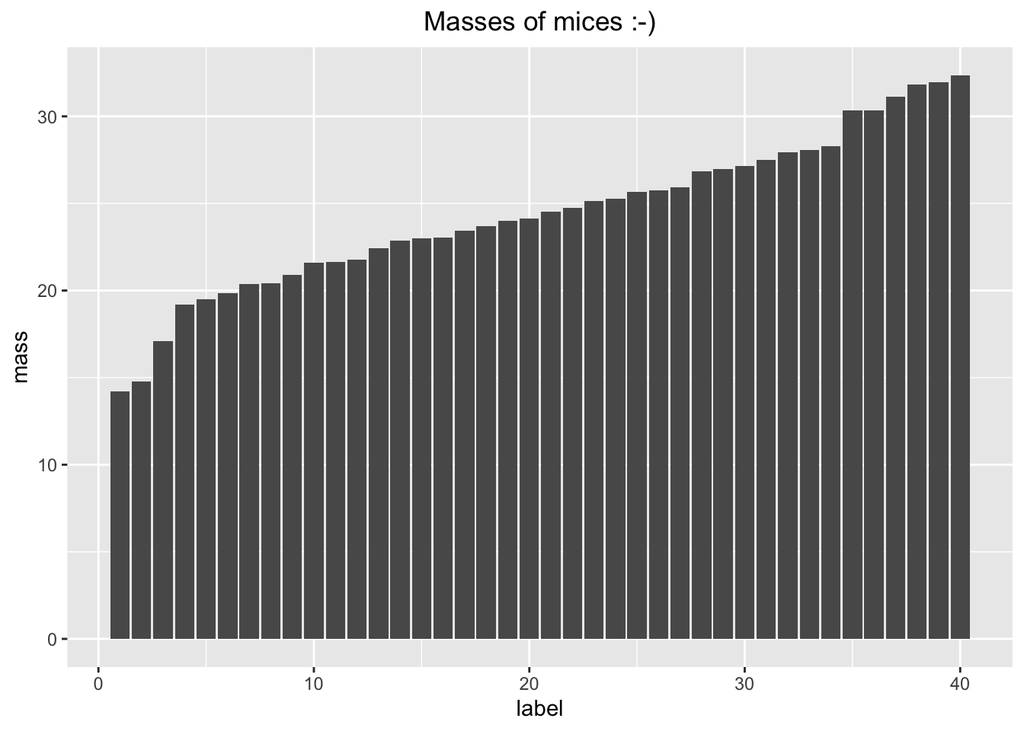

```r
ggplot(df,aes(x=label,y=mass)) + geom_col() + ggtitle("Masses of mices :-)") + theme(plot.title = element_text(hjust = 0.5))
```

### From Values to Differences from the Mean

Suppose now that for each mouse we instead plot the difference in mass from the cage mean.

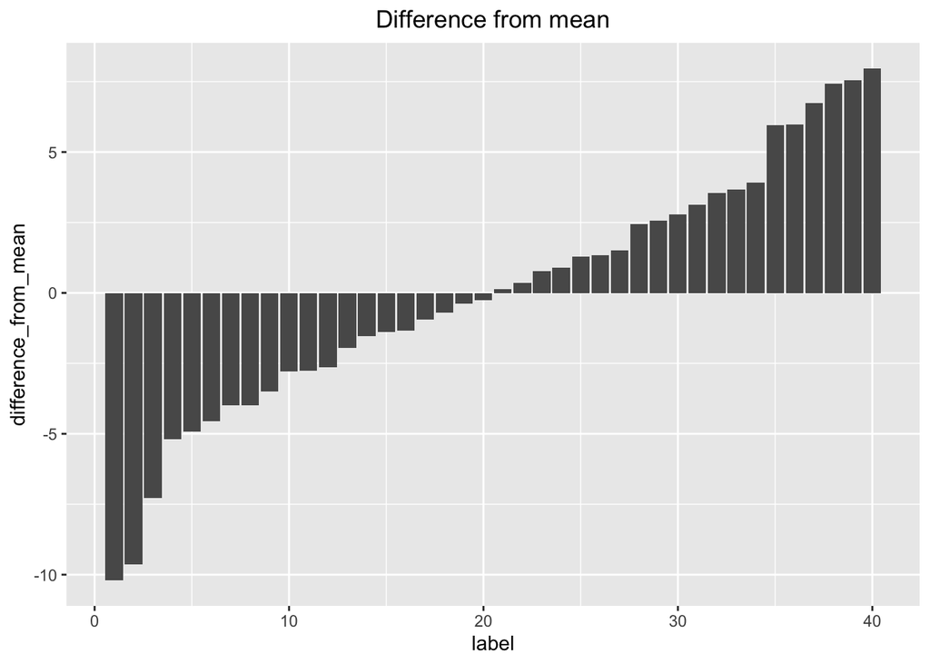

```r
df %>% mutate(difference_from_mean = mass - mean(mass)) %>% ggplot(aes(x=label,y=difference_from_mean)) + geom_col() + ggtitle("Difference from mean") + theme(plot.title = element_text(hjust = 0.5))
```

Suppose you were told the mean mass of the caged mice (i.e. `mean(df$mass)`) and then asked to predict the mass of a mouse randomly chosen from the cage. You might respond by asking what the penalty is for being wrong. In the preceding plot, difference_from_mean could be considered a reasonable measure of “wrongness”; however, negative “wrongness” is confusing and it doesn’t make sense for the average “wrongness” to be zero (**check this in R if it is not clear**). Instead, the most commonly used measure of “wrongness” comes from *squaring* the difference from mean. Let’s see what that looks like for our data.

```r
# Run this code block to observe that the average difference from mean is zero.
# --- Note that average and mean are the same and used interchangeably
# --- using the function round to remove very small rounding errors
df %>% mutate(difference_from_mean = mass - mean(mass)) %>% group_by() %>% summarise(average_difference_from_mean = round(mean(difference_from_mean),15))
```

```
## # A tibble: 1 × 1
##   average_difference_from_mean
##                          <dbl>
## 1                       -1e-15
```

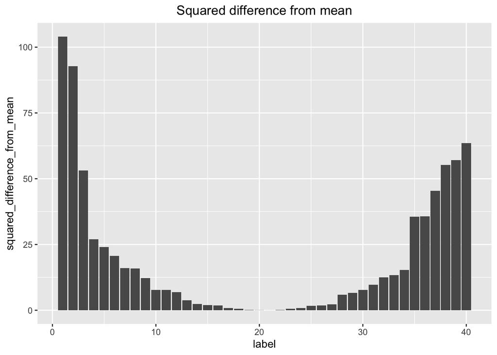

```r
df %>% mutate(squared_difference_from_mean = (mass - mean(mass))^2) %>% ggplot(aes(x=label,y=squared_difference_from_mean)) + geom_col()+ ggtitle("Squared difference from mean") + theme(plot.title = element_text(hjust = 0.5))
```

Now we have a non-negative measure of “wrongness” and it becomes meaningful to quantify how wrong we are on average. Let’s calculate that:

```r
df %>% mutate(squared_difference_from_mean = (mass - mean(mass))^2) %>% group_by() %>% summarise(average_squared_difference_from_mean = (mean(squared_difference_from_mean)))
```

```
## # A tibble: 1 × 1
##   average_squared_difference_from_mean
##                                  <dbl>
## 1                                 19.3
```

As you may already know, this number has a familiar name: **variance**.

```r
# compute the variance of mouse mass
# --- note that the R function var uses the denominator n_mice-1
# --- multiplying by (n_mice-1)/n_mice changes the denominator to n
variance_mass <- ((n_mice-1)/n_mice)*var(df$mass)
variance_mass
```

```
## [1] 19.26045
```

### An Intercept-Only Linear Model

Let’s consider our mouse-mass guessing game in a different way. Implicitly, what we are doing is modelling mass as a constant and then estimating the constant (red in the plot below) that best explains mass.

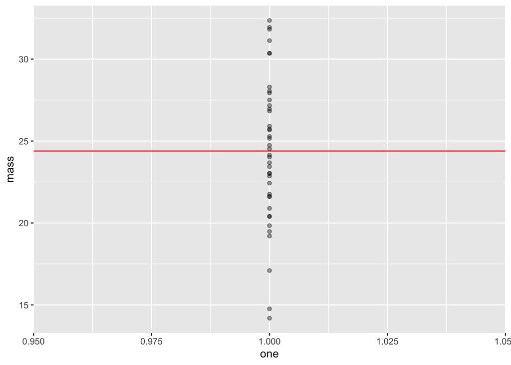

```r
df %>% add_column(one = 1) %>% ggplot(aes(x=one,y=mass)) + geom_point(alpha = 0.4) + geom_hline(yintercept=mean(df$mass), colour = "red")
```

We can see this arising from `lm()` as well. What we are doing here is fitting mass to a line with zero slope. We do indicate this with `mass ~ 1`, which tasks R to find the coefficient that, when multiplied to a constant vector of ones, best explains the variable mass.

```r
lm0 <- lm(mass ~ 1, data = df)
lm0
```

```
##
## Call:
## lm(formula = mass ~ 1, data = df)
##
## Coefficients:
## (Intercept)
##       24.39
```

The intercept of the model – that is, where the red line intersects the y-axis – is just the mean mass:

```r
mean(df$mass)
```

```
## [1] 24.39
```

The mean, or equivalently the intercept, is also the model-based prediction for every mouse:

```r
lm0$fitted.values
```

```
##     1     2     3     4     5     6     7     8     9    10    11    12    13
## 24.39 24.39 24.39 24.39 24.39 24.39 24.39 24.39 24.39 24.39 24.39 24.39 24.39
##    14    15    16    17    18    19    20    21    22    23    24    25    26
## 24.39 24.39 24.39 24.39 24.39 24.39 24.39 24.39 24.39 24.39 24.39 24.39 24.39
##    27    28    29    30    31    32    33    34    35    36    37    38    39
## 24.39 24.39 24.39 24.39 24.39 24.39 24.39 24.39 24.39 24.39 24.39 24.39 24.39
##    40
## 24.39
```

We can also evaluate the model using an analysis of variance:

```r
anova(lm0)
```

```
## Analysis of Variance Table
##
## Response: mass
##           Df Sum Sq Mean Sq F value Pr(>F)
## Residuals 39 770.42  19.754
```

The sum of squares (Sum Sq) is just the total “wrongness” from above!

```r
df %>% mutate(squared_difference_from_mean = (mass - mean(mass))^2) %>% group_by() %>% summarise(sum_of_squared_difference_from_mean = (sum(squared_difference_from_mean)))
```

```
## # A tibble: 1 × 1
##   sum_of_squared_difference_from_mean
##                                 <dbl>
## 1                                770.
```

The mean square is just the sum of squared divided by n_mice-1; that is, it is the result of the `var()` function in R:

```r
# as above, without changing the denominator
var(df$mass)
```

```
## [1] 19.75431
```

### Male and Female Mice

Now assume, hypothetically of course, that there are an equal number of male and female mice, and that all of the male mice are heavier than all of the female mice.

```r
df <- add_column(df,sex = factor(c(rep("FEMALE",n_mice/2),rep("MALE",n_mice/2))))
head(df)
```

```
## # A tibble: 6 × 3
##   label  mass sex
##   <int> <dbl> <fct>
## 1     1  14.2 FEMALE
## 2     2  14.8 FEMALE
## 3     3  17.1 FEMALE
## 4     4  19.2 FEMALE
## 5     5  19.5 FEMALE
## 6     6  19.8 FEMALE
```

### Sex-Specific Mean Differences

Supposing we were to play the same guessing game as before, would knowing the sex help you to predict the mass of a mouse randomly chosen from the cage? The answer is obviously yes! Predicting mass *conditional on sex* reduces our “wrongness” because the individual masses are much closer to their sex-specific means than they are to the overall mean. Let’s try to visualise that as above, and check out the nifty wrangling!

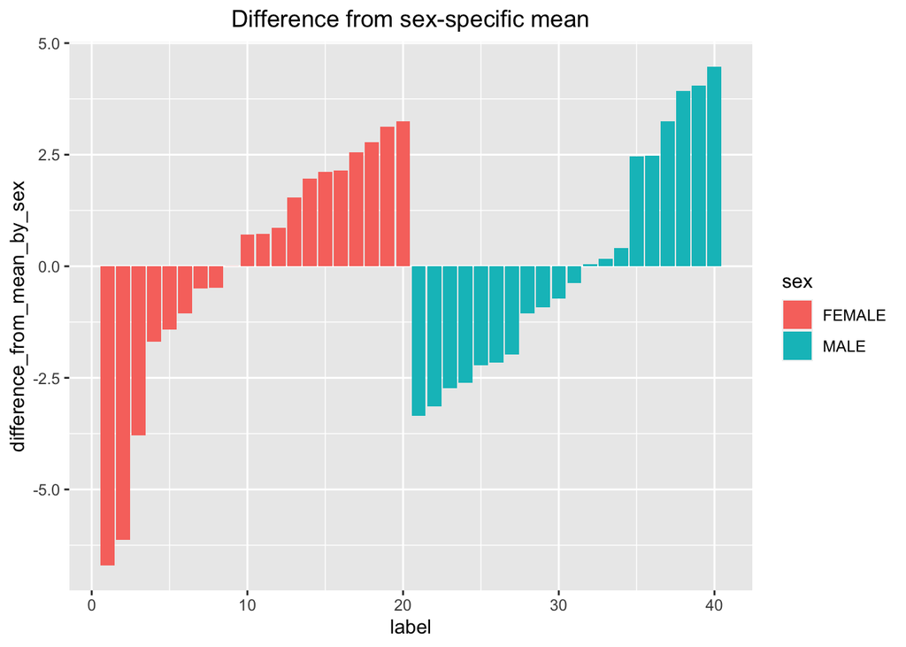

```r
df %>% group_by(sex) %>% mutate(difference_from_mean_by_sex = mass - mean(mass)) %>% ggplot(aes(x=label,y=difference_from_mean_by_sex,fill=sex)) + geom_col() + ggtitle("Difference from sex-specific mean") + theme(plot.title = element_text(hjust = 0.5))
```

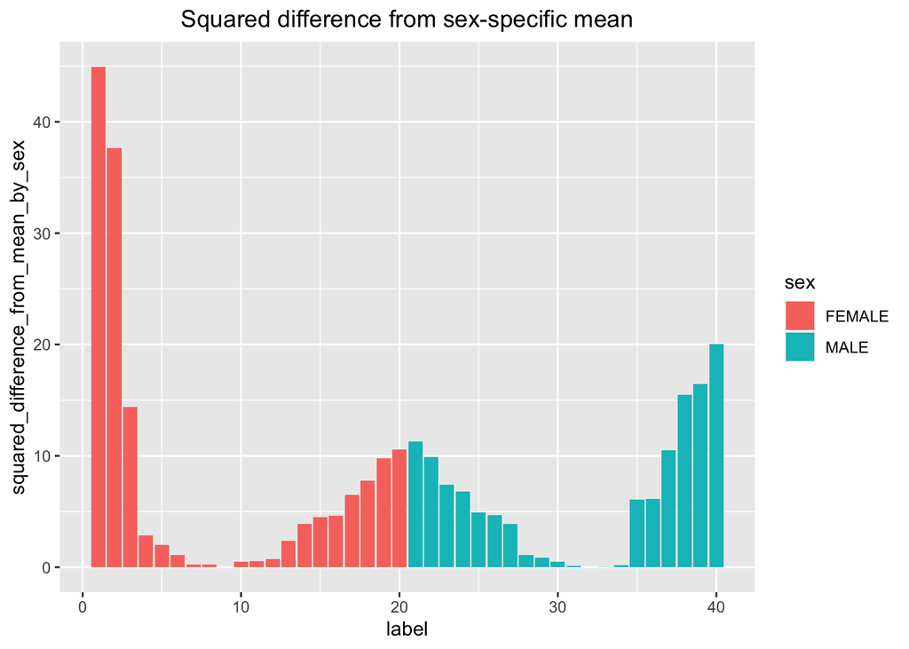

```r
df %>% group_by(sex) %>% mutate(squared_difference_from_mean_by_sex = (mass - mean(mass))^2) %>% ggplot(aes(x=label,y=squared_difference_from_mean_by_sex,fill=sex)) + geom_col() + ggtitle("Squared difference from sex-specific mean") + theme(plot.title = element_text(hjust = 0.5))
```

Let’s quickly compute our total “wrongness” when we are allowed to predict after knowing the sex:

```r
df %>% group_by(sex) %>% mutate(squared_difference_from_mean = (mass - mean(mass))^2) %>% group_by() %>% summarise(sum_of_squared_difference_from_mean = (sum(squared_difference_from_mean)))
```

```
## # A tibble: 1 × 1
##   sum_of_squared_difference_from_mean
##                                 <dbl>
## 1                                281.
```

### A Model with an Intercept and a Difference from the Intercept

This time, what we are doing is modelling mass as a constant for each sex and then estimating the constants that best explains sex-specific mass.

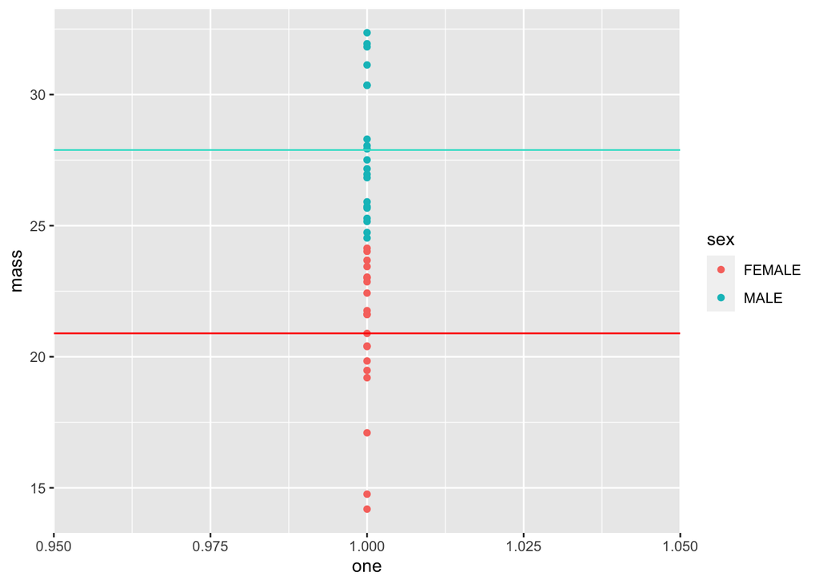

```r
sex_specific_means <- df %>% group_by(sex) %>% summarise(val = mean(mass)) %>% pull(val)
df %>% add_column(one = 1) %>% ggplot(aes(x=one,y=mass,colour=sex)) + geom_point() + geom_hline(yintercept=sex_specific_means[1],colour="red") + geom_hline(yintercept=sex_specific_means[2],colour="turquoise")
```

Let’s now approach this with a linear model. This time we fitting female mass to one line with zero slope and male mass to another line with zero slope.

```r
lm1 <- lm(mass ~ sex, data = df)
lm1
```

```
##
## Call:
## lm(formula = mass ~ sex, data = df)
##
## Coefficients:
## (Intercept)      sexMALE
##      20.893        6.993
```

Take a look at the coefficients. The coefficient “Intercept” is the mean mass among female mice (i.e. `sex_specific_means[1]`) and corresponds to the red line in the plot above. Why is this the intercept?

```r
levels(df$sex)
```

```
## [1] "FEMALE" "MALE"
```

Because of how we constructed the dataset, FEMALE is the first level of the factor sex. For this reason, FEMALE is chosen as the intercept. By contrast, the coefficient “sexMALE” is the *difference* between the mean mass among male mice and the mean mass among female mice (i.e. `sex_specific_means[2] - sex_specific_means[1]`) and corresponds to the height difference between the blue line and the red line.

There is a good reason to choose as parameters an arbitrary intercept and differences. This is because the goal is often to *test* for a difference between levels rather than to *infer* the mean of each level. Even so, the means are more intuitive, and for that reason the package `emmeans` can be very useful.

```r
emmeans(lm1,~sex)
```

```
##  sex    emmean    SE df lower.CL upper.CL
##  FEMALE   20.9 0.608 38     19.7     22.1
##  MALE     27.9 0.608 38     26.7     29.1
##
## Confidence level used: 0.95
```

Observe that the column “emmean” reports the means of female and male mice, as compared to the coefficients reported in the linear model.

### The ANOVA Interpretation

Now let’s inspect the analysis of variance table:

```r
anova(lm1)
```

```
## Analysis of Variance Table
##
## Response: mass
##           Df Sum Sq Mean Sq F value    Pr(>F)
## sex        1 489.02  489.02  66.037 7.783e-10 ***
## Residuals 38 281.40    7.41
## ---
## Signif. codes:  0 '***' 0.001 '**' 0.01 '*' 0.05 '.' 0.1 ' ' 1
```

OK, let’s break this down. Start with the sum of squares for Residuals and notice that this is exactly our total “wrongness” when we are allowed to predict after knowing the sex. Moreover, when we add the sums of squares for sex and Residuals, we get our total “wrongness” from before we had knowledge of the sex. The column “Df”, short for degrees of freedom, is a bit of statistical bookkeeping. We start with 40 mice and effectively spend one degree of freedom to compute the overall mean. In parallel to the plot sequence above, imagine that by computing the mean, we are subsequently considering differences in mass from the mean rather than the masses themselves. Because these differences sum to zero (see above), once we know 39 of them, we can solve for the remaining one. Thus, the actual *degrees of freedom* is 39. When we include sex, we use/lose one more degree of freedom, because knowing the overall mean and the mean mass of one sex allows us to compute the mean mass of the other. This leaves 38 residual degrees of freedom.

The word “Residual”, by definition, means what’s left over. We actually computed the residuals already when we created the plotting variable `difference_from_mean_by_sex`. This time, let’s extract them from the linear model and take their variance:

```r
var(lm1$residuals)
```

```
## [1] 7.215326
```

You’ll notice that this is close to, but not quite, the value listed for Residuals under Mean Sq. The issue, once again, is the denominator, and this is why we calculated the degrees of freedom:

```r
# Computing Mean Sq by gently scaling the variance
((n_mice-1)/(n_mice-2))*var(lm1$residuals)
```

```
## [1] 7.405203
```

```r
# Computing Mean Sq from the anova table
# --- note the use of clean_names, and consider what happens when you don't use it
aov1 <- clean_names(anova(lm1))
aov1$sum_sq[2]/aov1$df[2]
```

```
## [1] 7.405203
```

### Equality of Approaches in the Simple Case

```r
t0 <- t.test(df %>% filter(sex=="FEMALE") %>% pull(mass),df %>% filter(sex=="MALE") %>% pull(mass),var.equal = TRUE)
t0
```

```
##
##  Two Sample t-test
##
## data:  df %>% filter(sex == "FEMALE") %>% pull(mass) and df %>% filter(sex == "MALE") %>% pull(mass)
## t = -8.1263, df = 38, p-value = 7.783e-10
## alternative hypothesis: true difference in means is not equal to 0
## 95 percent confidence interval:
##  -8.735062 -5.250938
## sample estimates:
## mean of x mean of y
##   20.8935   27.8865
```

Observe that the p-values for both tests are the same, and that the F value is simply the square of the t statistic. Note also that the setting `var.equal = TRUE`, which is an assumption of the linear model: the variance is assumed to be the same across levels of a factor, in this case sex. Speaking of the linear model, we can also find the t statistic there, although in parallel to the F value it is referenced as the t value.

```r
summary(lm1)
```

```
##
## Call:
## lm(formula = mass ~ sex, data = df)
##
## Residuals:
##    Min     1Q Median     3Q    Max
## -6.704 -1.764  0.020  2.226  4.473
##
## Coefficients:
##             Estimate Std. Error t value Pr(>|t|)
## (Intercept)  20.8935     0.6085  34.337  < 2e-16 ***
## sexMALE       6.9930     0.8605   8.126 7.78e-10 ***
## ---
## Signif. codes:  0 '***' 0.001 '**' 0.01 '*' 0.05 '.' 0.1 ' ' 1
##
## Residual standard error: 2.721 on 38 degrees of freedom
## Multiple R-squared:  0.6347, Adjusted R-squared:  0.6251
## F-statistic: 66.04 on 1 and 38 DF,  p-value: 7.783e-10
```

We are also provided an R-squared value, which is generally interpreted as the proportion of variance explained by the model. Loosely speaking, this quantifies how well the model reduces our “wrongness”. We can compute this is a couple of ways:

```r
aov1$sum_sq[1]/(sum(aov1$sum_sq))
```

```
## [1] 0.6347468
```

```r
1 - var(lm1$residuals)/var(df$mass)
```

```
## [1] 0.6347468
```

### Adding a Second Factor

We began in consideration of mouse mass, a response variable that we sought to predict/explain. We then introduced an explanatory variable, sex, as a factor with two levels (FEMALE and MALE). We now imagine trialing an experimental obesity drug on the mice by introducing a second factor, treatment (trt for short), with the levels CONTROL and TREATMENT. Let’s keep the number of mice at 40 and assume an equal number of mice in each of the four classes as in the table below:

```r
tt <- matrix(c(n_mice/4,n_mice/4,n_mice/4,n_mice/4),2,2)
colnames(tt) <- c("CONTROL","TREATMENT")
rownames(tt) <- c("FEMALE","MALE")
kable(tt)
```

|  | CONTROL | TREATMENT |
| --- | --- | --- |
| FEMALE | 10 | 10 |
| MALE | 10 | 10 |

We first consider an **additive** model that has no interaction term. Following the convention in R, we will first specify the mean mass among control females (the intercept). Then we specify both the mean difference between males and females and the mean difference between treatment and control. Let’s assume that males are on average heavier and that the treatment is an obesity drug that leads to a mean weight reduction. Finally, we’ll also need to specify how much variation there is around these means.

```r
# mean of CONTROL & FEMALE
intercept <- 28
# change in mean CONTROL -> TREATMENT
treatment_effect <- -5
# change in mean FEMALE -> MALE
sex_effect <- 3
# standard deviation around means
noise <- 2
two_factor <- tibble(mouse_id = 1:n_mice, sex = c(rep("FEMALE",n_mice/2),rep("MALE",n_mice/2)), trt = rep(c(rep("CONTROL",n_mice/4),rep("TREATMENT",n_mice/4)),2)) %>% mutate(mass = ifelse(trt == "CONTROL",intercept,intercept+treatment_effect)) %>% mutate(mass = ifelse(sex == "FEMALE",mass,mass+sex_effect)) %>% mutate(mass = mass + rnorm(n_mice,0,noise))
two_factor
```

```
## # A tibble: 40 × 4
##    mouse_id sex    trt      mass
##       <int> <chr>  <chr>   <dbl>
##  1        1 FEMALE CONTROL  27.2
##  2        2 FEMALE CONTROL  24.1
##  3        3 FEMALE CONTROL  26.3
##  4        4 FEMALE CONTROL  31.8
##  5        5 FEMALE CONTROL  29.2
##  6        6 FEMALE CONTROL  32.0
##  7        7 FEMALE CONTROL  27.4
##  8        8 FEMALE CONTROL  27.8
##  9        9 FEMALE CONTROL  27.6
## 10       10 FEMALE CONTROL  25.6
## # … with 30 more rows
```

Let’s look at the treatment effect by sex:

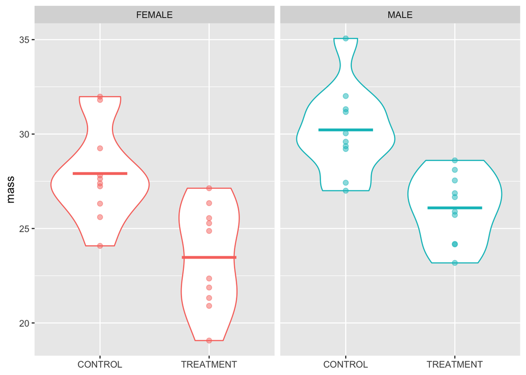

```r
ggplot(two_factor,aes(x = trt, y = mass, colour = sex)) + geom_violin() + geom_point(size=2,alpha=0.5) + stat_summary(fun = "mean",
               geom = "crossbar",
               width = 0.5) + theme(axis.title.x=element_blank(),legend.position = "none") + facet_wrap(~sex)
```

The left panel illustrates the treatment effect among females as the mean difference between TREATMENT and CONTROL groups. The right panel illustrates the treatment effect among males as the mean difference between TREATMENT and CONTROL groups. The data suggests that the model is additive because the treatment effect appears consistent across males and females.

Let’s confirm our observations with `lm()`:

```r
lm_two_factor <- lm(mass ~ sex+trt+sex:trt,data=two_factor)
summary(lm_two_factor)
```

```
##
## Call:
## lm(formula = mass ~ sex + trt + sex:trt, data = two_factor)
##
## Residuals:
##     Min      1Q  Median      3Q     Max
## -4.4021 -1.6727 -0.2391  1.5372  4.8435
##
## Coefficients:
##                      Estimate Std. Error t value Pr(>|t|)
## (Intercept)           27.9107     0.7473  37.348  < 2e-16 ***
## sexMALE                2.3083     1.0568   2.184 0.035548 *
## trtTREATMENT          -4.4403     1.0568  -4.201 0.000167 ***
## sexMALE:trtTREATMENT   0.3132     1.4946   0.210 0.835193
## ---
## Signif. codes:  0 '***' 0.001 '**' 0.01 '*' 0.05 '.' 0.1 ' ' 1
##
## Residual standard error: 2.363 on 36 degrees of freedom
## Multiple R-squared:  0.5488, Adjusted R-squared:  0.5112
## F-statistic: 14.59 on 3 and 36 DF,  p-value: 2.223e-06
```

The additive model does not include a sex:trt interaction term. We explicitly included this term in `lm()` in order to observe whether the coefficient sexMALE:trtTREATMENT was significantly different from zero. We could have specified the additive model directly with `lm(mass ~ sex + trt)`. The model we used instead, including the interaction term, can also be specified with `lm(mass ~ sex * trt)`.

Before we move on, let’s also call emmeans to get the estimated means for each class. How do these compare to the coefficients returned by `lm()`? Can you figure out what sexMALE:trtTREATMENT represents?

```r
emmeans(lm_two_factor, ~sex*trt)
```

```
##  sex    trt       emmean    SE df lower.CL upper.CL
##  FEMALE CONTROL     27.9 0.747 36     26.4     29.4
##  MALE   CONTROL     30.2 0.747 36     28.7     31.7
##  FEMALE TREATMENT   23.5 0.747 36     22.0     25.0
##  MALE   TREATMENT   26.1 0.747 36     24.6     27.6
##
## Confidence level used: 0.95
```

Let’s next try out a model the includes an interaction term. Before we specified the change in mean CONTROL -> TREATMENT and the change in mean FEMALE -> MALE. When these factors interact, we need to go further.

```r
# mean of CONTROL & FEMALE
intercept <- 28
# change in mean FEMALE -> MALE
sex_effect <- 3
# change in mean CONTROL -> TREATMENT among FEMALES
treatment_effect_female <- -5
# change in mean CONTROL -> TREATMENT among MALES
treatment_effect_male <- -1
# standard deviation around means
noise <- 2
two_factor_interaction <- tibble(mouse_id = 1:n_mice, sex = c(rep("FEMALE",n_mice/2),rep("MALE",n_mice/2)), trt = rep(c(rep("CONTROL",n_mice/4),rep("TREATMENT",n_mice/4)),2)) %>% mutate(mass = ifelse(sex == "FEMALE",intercept,intercept+sex_effect)) %>% mutate(mass = ifelse(trt == "CONTROL",mass,ifelse(sex == "FEMALE",mass+treatment_effect_female,mass+treatment_effect_male))) %>% mutate(mass = mass + rnorm(n_mice,0,noise))
two_factor_interaction
```

```
## # A tibble: 40 × 4
##    mouse_id sex    trt      mass
##       <int> <chr>  <chr>   <dbl>
##  1        1 FEMALE CONTROL  30.0
##  2        2 FEMALE CONTROL  24.6
##  3        3 FEMALE CONTROL  26.9
##  4        4 FEMALE CONTROL  25.3
##  5        5 FEMALE CONTROL  23.6
##  6        6 FEMALE CONTROL  31.6
##  7        7 FEMALE CONTROL  26.7
##  8        8 FEMALE CONTROL  27.4
##  9        9 FEMALE CONTROL  27.2
## 10       10 FEMALE CONTROL  28.8
## # … with 30 more rows
```

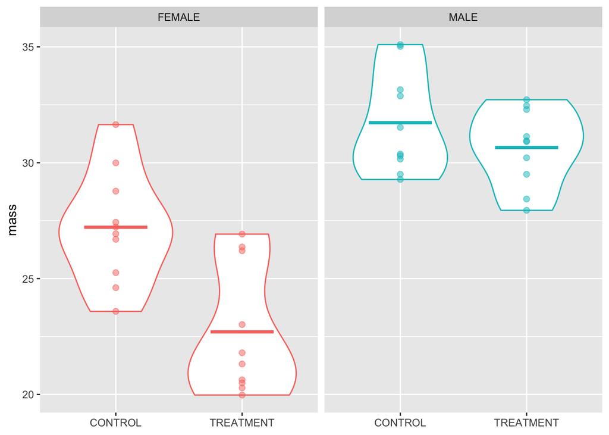

```r
ggplot(two_factor_interaction,aes(x = trt, y = mass, colour = sex)) + geom_violin() + geom_point(size=2,alpha=0.5) + stat_summary(fun = "mean",
               geom = "crossbar",
               width = 0.5) + theme(axis.title.x=element_blank(),legend.position = "none") + facet_wrap(~sex)
```

Can you tell that there is an interaction? What about the plot gives it away?

```r
lm_two_factor_interact <- lm(mass ~ sex*trt,data=two_factor)
summary(lm_two_factor_interact)
```

```
##
## Call:
## lm(formula = mass ~ sex * trt, data = two_factor)
##
## Residuals:
##     Min      1Q  Median      3Q     Max
## -4.4021 -1.6727 -0.2391  1.5372  4.8435
##
## Coefficients:
##                      Estimate Std. Error t value Pr(>|t|)
## (Intercept)           27.9107     0.7473  37.348  < 2e-16 ***
## sexMALE                2.3083     1.0568   2.184 0.035548 *
## trtTREATMENT          -4.4403     1.0568  -4.201 0.000167 ***
## sexMALE:trtTREATMENT   0.3132     1.4946   0.210 0.835193
## ---
## Signif. codes:  0 '***' 0.001 '**' 0.01 '*' 0.05 '.' 0.1 ' ' 1
##
## Residual standard error: 2.363 on 36 degrees of freedom
## Multiple R-squared:  0.5488, Adjusted R-squared:  0.5112
## F-statistic: 14.59 on 3 and 36 DF,  p-value: 2.223e-06
```

We can also look at the analysis of variance table:

```r
anova(lm_two_factor_interact)
```

```
## Analysis of Variance Table
##
## Response: mass
##           Df  Sum Sq Mean Sq F value    Pr(>F)
## sex        1  60.758  60.758 10.8794  0.002196 **
## trt        1 183.501 183.501 32.8582 1.585e-06 ***
## sex:trt    1   0.245   0.245  0.0439  0.835193
## Residuals 36 201.047   5.585
## ---
## Signif. codes:  0 '***' 0.001 '**' 0.01 '*' 0.05 '.' 0.1 ' ' 1
```

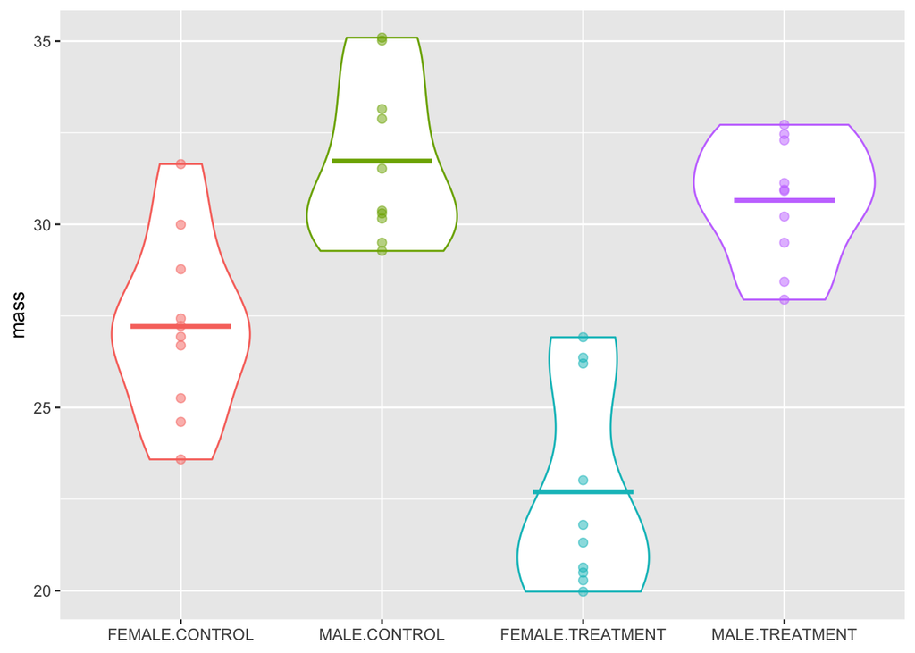

```r
ggplot(two_factor_interaction,aes(x = interaction(sex,trt), y = mass, colour = interaction(sex,trt))) + geom_violin() + geom_point(size=2,alpha=0.5) + stat_summary(fun = "mean", geom = "crossbar", width = 0.5) + theme(axis.title.x=element_blank(),legend.position = "none")
```

Compare that to what happens when the data is grouped together!

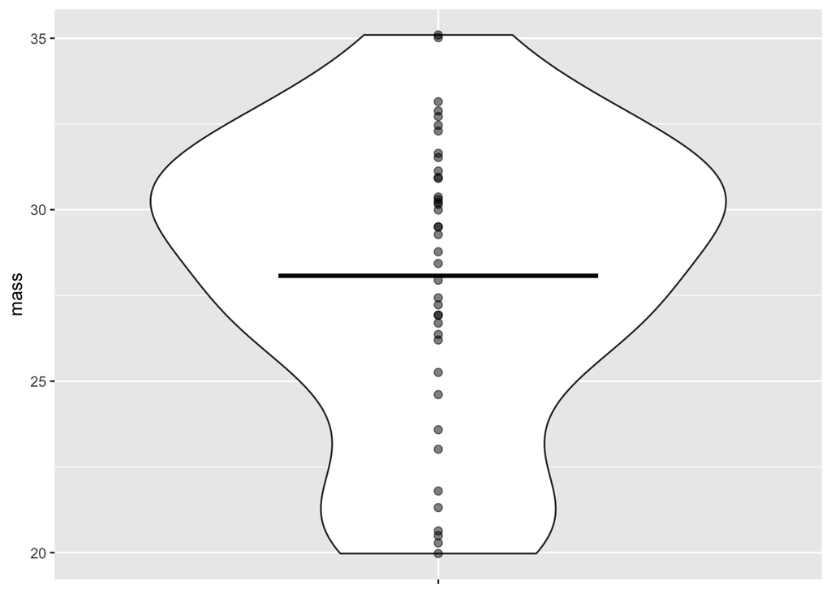

```r
ggplot(two_factor_interaction,aes(x = factor(1), y = mass)) + geom_violin() + geom_point(size=2,alpha=0.5) + stat_summary(fun = "mean",
               geom = "crossbar",
               width = 0.5) + theme(axis.title.x=element_blank(),axis.text.x=element_blank(),legend.position = "none")
```

### Introducing a Continuous Predictor

Let’s next introduce age as a continuous predictor; in other words, mouse age will be an explanatory variable but not a factor with discrete levels. We’ll imagine that mice get heavier with age and that male mice get heavier with age faster.

```r
# mean weight of newborn mouse in grams
intercept <- 5
# mean daily increase in mass for females
female_slope <- 1
# mean daily increase in mass for males
male_slope <- 1.4
# standard deviation around means
noise <- 2
age_sex_df <- tibble(mouse_id = 1:n_mice, age = rpois(n_mice,20), sex = c(rep("FEMALE",n_mice/2),rep("MALE",n_mice/2))) %>% mutate(mass = ifelse(sex == "FEMALE",intercept+age*female_slope,intercept+age*male_slope)) %>% mutate(mass = mass + rnorm(n_mice,0,noise))
age_sex_df
```

```
## # A tibble: 40 × 4
##    mouse_id   age sex     mass
##       <int> <int> <chr>  <dbl>
##  1        1    25 FEMALE  30.1
##  2        2    20 FEMALE  25.6
##  3        3    27 FEMALE  30.2
##  4        4    18 FEMALE  21.7
##  5        5    15 FEMALE  19.5
##  6        6    26 FEMALE  29.1
##  7        7    23 FEMALE  29.6
##  8        8    10 FEMALE  11.8
##  9        9    20 FEMALE  22.9
## 10       10    26 FEMALE  28.5
## # … with 30 more rows
```

Let’s take a look at this using our old friend `geom_smooth()`:

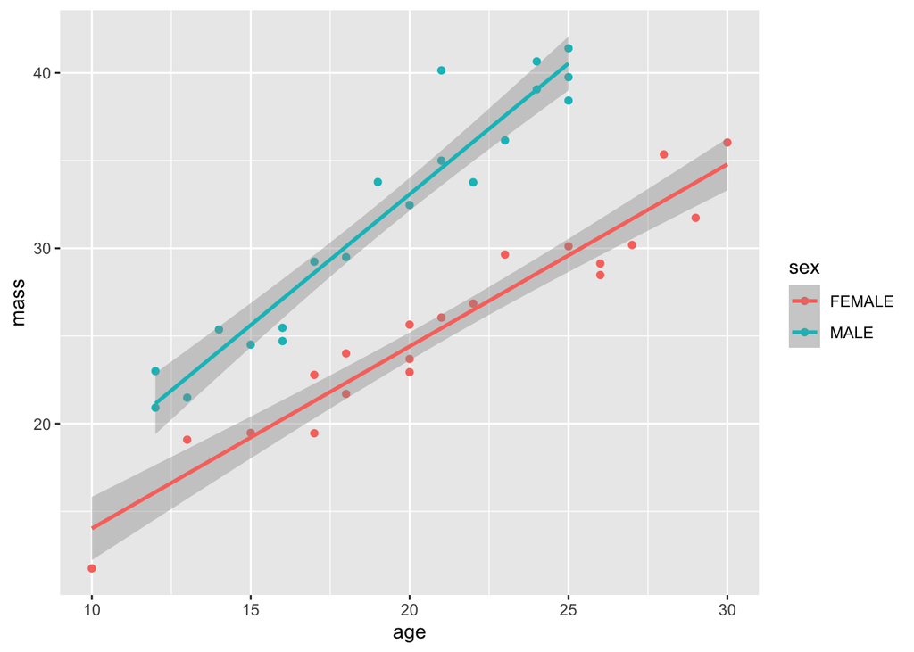

```r
ggplot(age_sex_df,aes(x=age,y=mass,colour=sex)) + geom_point() + geom_smooth(method="lm")
```

The unequal slopes in this plot are analogous to the inconsistent mean differences observed in the two factor example. This is evidence of an interaction, and indeed we created the interaction by setting female_slope and male_slope to be different.

Let’s check with `lm()`:

```r
lm_age_sex <- lm(mass ~ age*sex, data = age_sex_df)
summary(lm_age_sex)
```

```
##
## Call:
## lm(formula = mass ~ age * sex, data = age_sex_df)
##
## Residuals:
##     Min      1Q  Median      3Q     Max
## -2.4046 -1.4725 -0.1092  1.2401  5.5685
##
## Coefficients:
##             Estimate Std. Error t value Pr(>|t|)
## (Intercept)  3.64213    1.65565   2.200  0.03432 *
## age          1.03827    0.07555  13.743 6.84e-16 ***
## sexMALE     -0.39793    2.44332  -0.163  0.87154
## age:sexMALE  0.45359    0.11878   3.819  0.00051 ***
## ---
## Signif. codes:  0 '***' 0.001 '**' 0.01 '*' 0.05 '.' 0.1 ' ' 1
##
## Residual standard error: 1.81 on 36 degrees of freedom
## Multiple R-squared:  0.9401, Adjusted R-squared:  0.9351
## F-statistic: 188.3 on 3 and 36 DF,  p-value: < 2.2e-16
```

Let’s try to make sense on the coefficients. The intercept corresponds to the mean mass of newborn females (age 0). The coefficient sexMALE corresponds to the difference in mass between newborn males and newborn females. The coefficient age is the slope when female mass is regressed on female age. The coefficient age:sexMALE is the difference is slope when instead male mass is regressed on male age. All of this is implied in the plot, and in fact `geom_smooth(method="lm")` is showing both of these regression lines. That’s what method=“lm” means!

### Putting it all together

Now let’s return to the fictional experiment by reintroducing treatment as a factor. We’ll take this one step further by conducting the experiment on mice of various ages and measuring the change in mass across two time points. We’ll let age and sex determine the mass at the start of the experiment (before) and let age and treatment determine how mass changes in the course of the 14-day experiment (after-before).

```r
# mean weight of newborn mouse in grams
intercept <- 5
# mean daily increase in mass for females
female_slope <- 1
# mean daily increase in mass for males
male_slope <- 1.4

# let's assume that the treatment reduces the slope of weight gain by 0.5 in both sexes
delta_treatment_slope <- -0.5
days <- 14

# standard deviation around means
noise <- 2

age_sex_trt_df <- tibble(mouse_id = 1:n_mice, age = rpois(n_mice,20), sex = c(rep("FEMALE",n_mice/2),rep("MALE",n_mice/2)), trt = rep(c(rep("CONTROL",n_mice/4),rep("TREATMENT",n_mice/4)),2)) %>% mutate(before = ifelse(sex == "FEMALE",intercept+age*female_slope,intercept+age*male_slope)) %>% mutate(before = before + rnorm(n_mice,0,noise)) %>% mutate(after = ifelse(trt == "CONTROL",ifelse(sex == "FEMALE",before+(days*female_slope),before+(days*male_slope)),ifelse(sex == "FEMALE",before+(days*(female_slope+delta_treatment_slope)),before+(days*(male_slope+delta_treatment_slope))))) %>% mutate(after = after + rnorm(n_mice,0,noise))
age_sex_trt_df
```

```
## # A tibble: 40 × 6
##    mouse_id   age sex    trt     before after
##       <int> <int> <chr>  <chr>    <dbl> <dbl>
##  1        1    28 FEMALE CONTROL   32.7  45.3
##  2        2    13 FEMALE CONTROL   20.7  34.0
##  3        3    13 FEMALE CONTROL   17.8  31.2
##  4        4    25 FEMALE CONTROL   29.4  45.1
##  5        5    14 FEMALE CONTROL   15.2  25.4
##  6        6    25 FEMALE CONTROL   28.7  44.2
##  7        7    19 FEMALE CONTROL   21.2  36.8
##  8        8    16 FEMALE CONTROL   24.9  39.3
##  9        9    16 FEMALE CONTROL   21.9  37.8
## 10       10    20 FEMALE CONTROL   26.1  42.5
## # … with 30 more rows
```

Wow, that was some crazy code. Let’s attempt to visualise what we’ve created. As we’ve experienced in the past, ggplot requires “before” and “after” to be stacked in a column. Use `pivot_longer()` to combine them into a single column named “time” (a factor) whose values are called “mass”.

```r
age_sex_trt_df_long <- pivot_longer(age_sex_trt_df,cols = c("before","after"),names_to="time",values_to="mass") %>% mutate(time = as_factor(time))
head(age_sex_trt_df_long)
```

```
## # A tibble: 6 × 6
##   mouse_id   age sex    trt     time    mass
##      <int> <int> <chr>  <chr>   <fct>  <dbl>
## 1        1    28 FEMALE CONTROL before  32.7
## 2        1    28 FEMALE CONTROL after   45.3
## 3        2    13 FEMALE CONTROL before  20.7
## 4        2    13 FEMALE CONTROL after   34.0
## 5        3    13 FEMALE CONTROL before  17.8
## 6        3    13 FEMALE CONTROL after   31.2
```

The plot reveals strong treatment and sex effects. Is there also evidence of a treatment by sex effect?

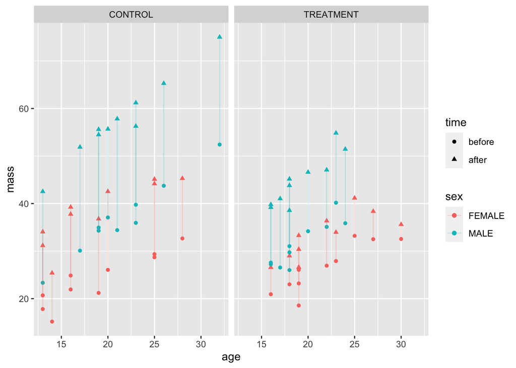

```r
ggplot(age_sex_trt_df_long,aes(x=age,y=mass,colour=sex,shape=time)) + geom_point() + geom_line(aes(group = mouse_id),alpha=.2) + facet_wrap(~trt)
```

As we like to do, let’s complement the plot with a model.

```r
lm_age_sex_trt <- lm(mass ~ age*sex*trt*time,data = age_sex_trt_df_long)
summary(lm_age_sex_trt)
```

```
##
## Call:
## lm(formula = mass ~ age * sex * trt * time, data = age_sex_trt_df_long)
##
## Residuals:
##     Min      1Q  Median      3Q     Max
## -7.7494 -1.2066  0.2163  1.2152  5.2548
##
## Coefficients:
##                                    Estimate Std. Error t value Pr(>|t|)
## (Intercept)                         6.61911    3.07186   2.155  0.03495 *
## age                                 0.91127    0.15674   5.814  2.1e-07 ***
## sexMALE                            -1.18046    4.74096  -0.249  0.80416
## trtTREATMENT                       -2.51814    5.27014  -0.478  0.63441
## timeafter                          12.22933    4.34427   2.815  0.00647 **
## age:sexMALE                         0.55181    0.22772   2.423  0.01822 *
## age:trtTREATMENT                    0.11553    0.24852   0.465  0.64361
## sexMALE:trtTREATMENT               -0.15742    8.58419  -0.018  0.98543
## age:timeafter                       0.11021    0.22166   0.497  0.62077
## sexMALE:timeafter                   5.58380    6.70474   0.833  0.40805
## trtTREATMENT:timeafter             -2.12244    7.45310  -0.285  0.77674
## age:sexMALE:trtTREATMENT           -0.09016    0.42004  -0.215  0.83073
## age:sexMALE:timeafter               0.03830    0.32204   0.119  0.90569
## age:trtTREATMENT:timeafter         -0.26906    0.35147  -0.766  0.44676
## sexMALE:trtTREATMENT:timeafter     -6.29786   12.13988  -0.519  0.60571
## age:sexMALE:trtTREATMENT:timeafter  0.32970    0.59403   0.555  0.58082
## ---
## Signif. codes:  0 '***' 0.001 '**' 0.01 '*' 0.05 '.' 0.1 ' ' 1
##
## Residual standard error: 2.57 on 64 degrees of freedom
## Multiple R-squared:  0.9613, Adjusted R-squared:  0.9522
## F-statistic: 105.9 on 15 and 64 DF,  p-value: < 2.2e-16
```

This is a mess. With so many coefficients (parameters) to estimate and so few data points (number of mice), this model is very difficult to fit. Moreover, as noted in the tutorial, it commits a serious error by treating the paired before/after measurements as two independent data points. The summary of the linear model notes more degrees of freedom than there are mice in the study, which to the trained eye should be a giant red flag.

As discussed on Monday, we can handle this by including mouse_id as a **random effect**. For now, however, we’ll simply summarise the paired measurements by a single new variable called change_in_mass.

```r
paired_age_sex_trt_df <- age_sex_trt_df %>% mutate(change_in_mass = after-before)
lm_paired_age_sex_trt <- lm(change_in_mass ~ age*sex*trt,data = paired_age_sex_trt_df)
summary(lm_paired_age_sex_trt)
```

```
##
## Call:
## lm(formula = change_in_mass ~ age * sex * trt, data = paired_age_sex_trt_df)
##
## Residuals:
##     Min      1Q  Median      3Q     Max
## -3.5430 -0.6410  0.0417  0.9500  2.8224
##
## Coefficients:
##                          Estimate Std. Error t value Pr(>|t|)
## (Intercept)              12.22933    1.88603   6.484 2.69e-07 ***
## age                       0.11021    0.09623   1.145   0.2606
## sexMALE                   5.58380    2.91082   1.918   0.0640 .
## trtTREATMENT             -2.12244    3.23572  -0.656   0.5166
## age:sexMALE               0.03830    0.13981   0.274   0.7859
## age:trtTREATMENT         -0.26906    0.15259  -1.763   0.0874 .
## sexMALE:trtTREATMENT     -6.29786    5.27045  -1.195   0.2409
## age:sexMALE:trtTREATMENT  0.32970    0.25789   1.278   0.2103
## ---
## Signif. codes:  0 '***' 0.001 '**' 0.01 '*' 0.05 '.' 0.1 ' ' 1
##
## Residual standard error: 1.578 on 32 degrees of freedom
## Multiple R-squared:  0.9293, Adjusted R-squared:  0.9138
## F-statistic:  60.1 on 7 and 32 DF,  p-value: < 2.2e-16
```

This is much better in that the degrees of freedom make sense (number of mice minus number of parameters). But we are still estimating many parameters with few data points, which makes it difficult to fit the model and also to conclude the presence of non-zero effects. Take a moment to test your understanding of the model from which the data was generated. Which coefficients are zero and which are nonzero?

To see the answer, let’s cheat and change this to a huge experiment.

```r
### Multiplying the number of mice by 10!
n_mice <- n_mice*10
# mean weight of newborn mouse in grams
intercept <- 5
# mean daily increase in mass for females
female_slope <- 1
# mean daily increase in mass for males
male_slope <- 1.4

# let's assume that the treatment reduces the slope of weight gain by 0.5 in both sexes
delta_treatment_slope <- -0.5
days <- 14

# standard deviation around means
noise <- 2

age_sex_trt_df <- tibble(mouse_id = 1:n_mice, age = rpois(n_mice,20), sex = c(rep("FEMALE",n_mice/2),rep("MALE",n_mice/2)), trt = rep(c(rep("CONTROL",n_mice/4),rep("TREATMENT",n_mice/4)),2)) %>% mutate(before = ifelse(sex == "FEMALE",intercept+age*female_slope,intercept+age*male_slope)) %>% mutate(before = before + rnorm(n_mice,0,noise)) %>% mutate(after = ifelse(trt == "CONTROL",ifelse(sex == "FEMALE",before+(days*female_slope),before+(days*male_slope)),ifelse(sex == "FEMALE",before+(days*(female_slope+delta_treatment_slope)),before+(days*(male_slope+delta_treatment_slope))))) %>% mutate(after = after + rnorm(n_mice,0,noise))
paired_age_sex_trt_df <- age_sex_trt_df %>% mutate(change_in_mass = after-before)
lm_paired_age_sex_trt <- lm(change_in_mass ~ age*sex*trt,data = paired_age_sex_trt_df)
summary(lm_paired_age_sex_trt)
```

```
##
## Call:
## lm(formula = change_in_mass ~ age * sex * trt, data = paired_age_sex_trt_df)
##
## Residuals:
##     Min      1Q  Median      3Q     Max
## -5.7933 -1.2935  0.0463  1.1480  6.0379
##
## Coefficients:
##                          Estimate Std. Error t value Pr(>|t|)
## (Intercept)              13.87367    0.94737  14.644  < 2e-16 ***
## age                       0.01838    0.04450   0.413    0.680
## sexMALE                   5.21390    1.31744   3.958 8.99e-05 ***
## trtTREATMENT             -8.82257    1.31070  -6.731 6.00e-11 ***
## age:sexMALE               0.01207    0.06272   0.192    0.848
## age:trtTREATMENT          0.07130    0.06162   1.157    0.248
## sexMALE:trtTREATMENT      0.97608    1.78753   0.546    0.585
## age:sexMALE:trtTREATMENT -0.03896    0.08518  -0.457    0.648
## ---
## Signif. codes:  0 '***' 0.001 '**' 0.01 '*' 0.05 '.' 0.1 ' ' 1
##
## Residual standard error: 1.959 on 392 degrees of freedom
## Multiple R-squared:  0.8476, Adjusted R-squared:  0.8449
## F-statistic: 311.4 on 7 and 392 DF,  p-value: < 2.2e-16
```

Now we can see which effects stand out. Recall that our response variable is change in mass. We created the model by assuming the males gained weight more quickly than females. We also assumed that the treatment reduced weight gain by the same amount in each sex. Thus, we observe a sex effect and a treatment effect, but no age effect and no interactions. With enough data, `lm()` has reproduced the generating model.

### An explicit random effect

Now let’s introduce what is unambiguously a random effect. To do so, we will assume that there are multiple cages of experimental mice. Perhaps some cages are more combative, impacting mean stress levels and weight gain. Perhaps this cage-to-cage variability for some other reason. To safeguard against this, and to acknowledge that a shared environment may jointly impact mice in the same cage, cage should be included as a factor in the model.

We’ll keep the dimensions of the larger experiment, imagining that the smaller experiment is replicated in each cage.

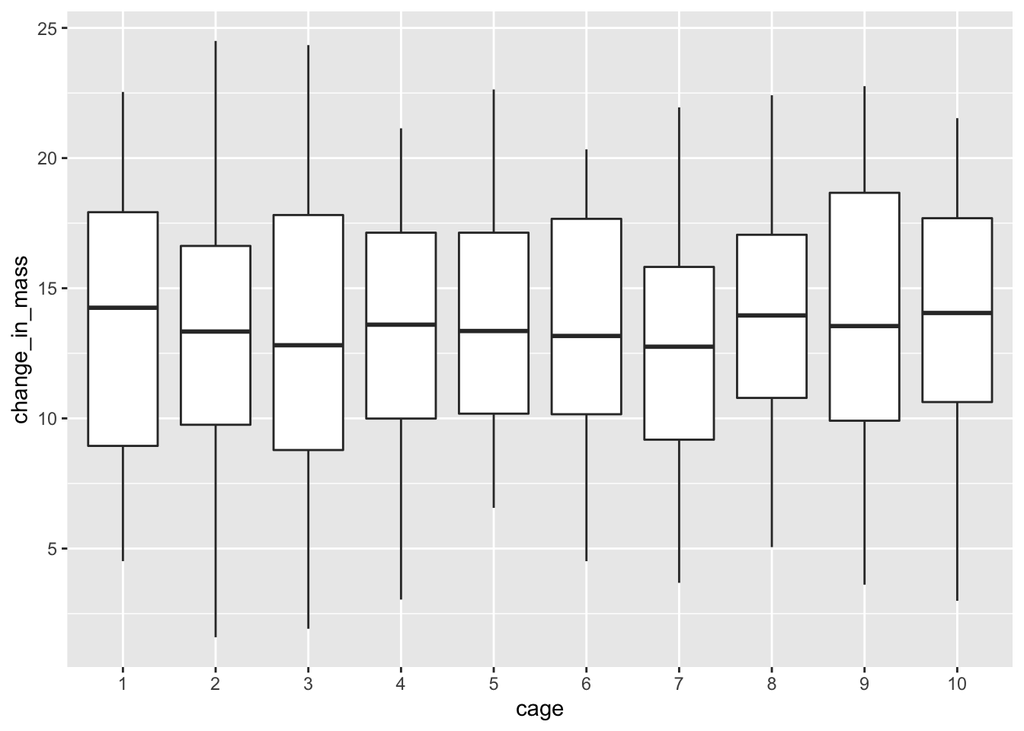

```r
# Remember that n_mice was multiplied by 10
cages_paired_age_sex_trt_df <- paired_age_sex_trt_df %>% mutate(cage = factor(rep(1:10,n_mice/10))) %>% arrange(cage)
ggplot(cages_paired_age_sex_trt_df,aes(x = cage,y = change_in_mass)) + geom_boxplot();
```

Now we’ll introduce a cage effect.

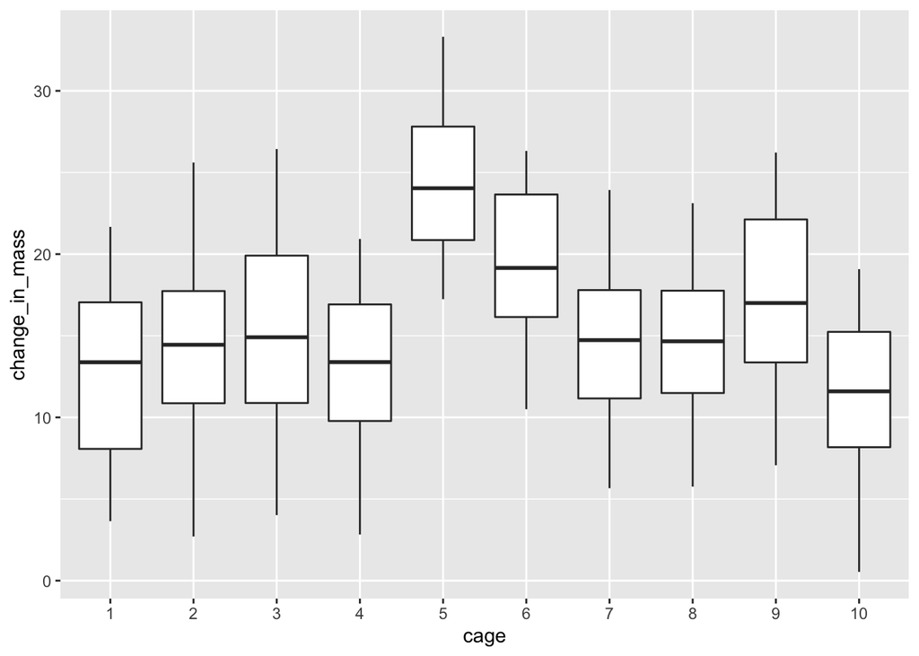

```r
sd_of_cage_effects <- 5
cage_effects <- rnorm(10,0,sd_of_cage_effects)
# Take a look at this line of code -- do you follow what it's doing?
cages_paired_age_sex_trt_df <- cages_paired_age_sex_trt_df %>% mutate(change_in_mass = change_in_mass + cage_effects[as.numeric(cage)])
ggplot(cages_paired_age_sex_trt_df,aes(x = cage,y = change_in_mass)) + geom_boxplot();
```

We literally made cage a random effect by sampling from the Normal distribution to obtain the change in change in mean for each cage. We could treat each of these cage-specific values as a parameter to be estimated in the model, but think about what this would mean for the model interpretation and our power. Just for demonstration purposes, lets fit that model using `lm()`

```r
lm_paired_age_sex_trt_cage <- lm(change_in_mass ~ cage+age*sex*trt,data = cages_paired_age_sex_trt_df)
summary(lm_paired_age_sex_trt_cage)
```

```
##
## Call:
## lm(formula = change_in_mass ~ cage + age * sex * trt, data = cages_paired_age_sex_trt_df)
##
## Residuals:
##     Min      1Q  Median      3Q     Max
## -5.2821 -1.2625  0.0252  1.1708  5.6240
##
## Coefficients:
##                            Estimate Std. Error t value Pr(>|t|)
## (Intercept)              13.0621394  0.9851902  13.258  < 2e-16 ***
## cage2                     1.6471899  0.4378967   3.762 0.000195 ***
## cage3                     2.4716556  0.4373896   5.651 3.12e-08 ***
## cage4                     0.7444633  0.4376956   1.701 0.089779 .
## cage5                    11.8989535  0.4367239  27.246  < 2e-16 ***
## cage6                     6.7177015  0.4371991  15.365  < 2e-16 ***
## cage7                     2.2355796  0.4387500   5.095 5.48e-07 ***
## cage8                     2.1015197  0.4385365   4.792 2.36e-06 ***
## cage9                     4.6392360  0.4373607  10.607  < 2e-16 ***
## cage10                   -1.4930930  0.4390763  -3.401 0.000743 ***
## age                       0.0166197  0.0449993   0.369 0.712085
## sexMALE                   5.4439713  1.3294356   4.095 5.15e-05 ***
## trtTREATMENT             -9.2530817  1.3307100  -6.953 1.55e-11 ***
## age:sexMALE               0.0006448  0.0633292   0.010 0.991881
## age:trtTREATMENT          0.0920422  0.0626135   1.470 0.142382
## sexMALE:trtTREATMENT      1.3257219  1.8046825   0.735 0.463032
## age:sexMALE:trtTREATMENT -0.0558216  0.0860433  -0.649 0.516881
## ---
## Signif. codes:  0 '***' 0.001 '**' 0.01 '*' 0.05 '.' 0.1 ' ' 1
##
## Residual standard error: 1.949 on 383 degrees of freedom
## Multiple R-squared:  0.904,  Adjusted R-squared:  0.8999
## F-statistic: 225.3 on 16 and 383 DF,  p-value: < 2.2e-16
```

As you can see, this is just a mess and we are using a total of 16 degrees of freedom here and over complicating the interpretation of our coefficients. Now, consider how cage effects came to be. We specified a single parameter, sd_of_cage_effects, and then sampled the cage-specific values from a Normal distribution with mean zero and standard deviation sd_of_cage_effects. Therefore, there is truly only a single parameter: one that governs the variability of the cage-specific values. When we model cage as a random effect, we use only this parameter (sd_of_cage_effects) rather than assigning a parameter to each cage. This does not change the other estimated coefficients; however, it impacts their significance by affecting the degrees of freedom. Recalling that the degrees of freedom are calculated as the difference between the number of data points and the number of parameters in the model, fewer parameters lead to greater degrees of freedom.

## Modelling cage as a random effect

If cage is best modeled as a random effect then how do we do this? `lm()` doesn’t provide a way for us to include random effects. We’ll need to resort to other packages for this. Remember, regardless of whether cage is a random effect or not, these are still just linear models. Keep that in mind as we move through…

We’ll introduce you to a couple of new packages that will allow you to extend the linear models you have already learnt to include random effects. The packages, `lme4` and `metafor` are both very useful for this purpose. We’ll actually use `metafor` in the coming weeks as it can also fit meta-analytic models and provide useful statistics relevant for meta-analysis.

First, lets download these new packages

```r
# Install and load the two packages we need. Remember to install these first.
library(lme4)
library(metafor)
library(lmerTest)
```

Now, lets start with `lme4` and fit cage as a random effect:

```r
# Lets fit a mixed effects model. We call this a mixed effects model because we are estimated both fixed and random effects.
model_mixed_lme <- lmer(change_in_mass ~ age*sex*trt + (1|cage), data = cages_paired_age_sex_trt_df)
summary(model_mixed_lme)
```

```
## Linear mixed model fit by REML. t-tests use Satterthwaite's method [
## lmerModLmerTest]
## Formula: change_in_mass ~ age * sex * trt + (1 | cage)
##    Data: cages_paired_age_sex_trt_df
##
## REML criterion at convergence: 1730.1
##
## Scaled residuals:
##      Min       1Q   Median       3Q      Max
## -2.71176 -0.65296  0.01337  0.60116  2.89016
##
## Random effects:
##  Groups   Name        Variance Std.Dev.
##  cage     (Intercept) 14.73    3.837
##  Residual              3.80    1.949
## Number of obs: 400, groups:  cage, 10
##
## Fixed effects:
##                            Estimate Std. Error         df t value Pr(>|t|)
## (Intercept)               16.176110   1.545617  23.173599  10.466 2.96e-10 ***
## age                        0.015772   0.044995 383.162014   0.351    0.726
## sexMALE                    5.426279   1.329313 383.140335   4.082 5.44e-05 ***
## trtTREATMENT              -9.272218   1.330534 383.201854  -6.969 1.40e-11 ***
## age:sexMALE                0.001494   0.063323 383.145599   0.024    0.981
## age:trtTREATMENT           0.092961   0.062605 383.210844   1.485    0.138
## sexMALE:trtTREATMENT       1.347643   1.804510 383.146019   0.747    0.456
## age:sexMALE:trtTREATMENT  -0.056880   0.086035 383.151204  -0.661    0.509
## ---
## Signif. codes:  0 '***' 0.001 '**' 0.01 '*' 0.05 '.' 0.1 ' ' 1
##
## Correlation of Fixed Effects:
##             (Intr) age    sxMALE tTREAT ag:MALE a:TREA sMALE:
## age         -0.606
## sexMALE     -0.448  0.708
## trTREATMENT -0.450  0.711  0.519
## age:sexMALE  0.432 -0.713 -0.978 -0.502
## a:TREATMENT  0.440 -0.725 -0.508 -0.978  0.512
## sMALE:TREAT  0.333 -0.527 -0.736 -0.737  0.720   0.721
## a:MALE:TREA -0.322  0.530  0.719  0.712 -0.735  -0.728 -0.976
```

There we go! That looks much cleaner. But what happened. You will notice a few very similar things.

1. First, the fixed effects are specified in the exact same way using the formula call. In this case, we used `change_in_mass ~ age*sex*trt`. That doesn’t change. And, you can see nor does the output from the model. The fixed effects are interpreted in exactly the same was as discussed above.
2. Second, you will notice that we still have our “Residual” estimated in both models.

There’s also some new things.

```r
VarCorr(model_mixed_lme)
```

```
##  Groups   Name        Std.Dev.
##  cage     (Intercept) 3.8373
##  Residual             1.9492
```

We can infer from this model that there is quite a lot to variation in mass change driven by the cage that mice are in, which makes sense as we added a cage effect here.

In the coming weeks we’ll use the `metafor` package to fit similar mixed / multilevel models. We can do that quite easily, but the syntax is a little different for random effects. The same model can be fit using the following code:

```r
# We first need to add an observation-level random effect because this is our "residual". Metafor doesn't add this by default.
cages_paired_age_sex_trt_df$residual <- 1:nrow(cages_paired_age_sex_trt_df)

model_mixed_metafor <- rma.mv(change_in_mass ~ age*sex*trt, V = 0,
                              random = list(~1|cage,
                                            ~1|residual), dfs = "contain",
                   test="t", data = cages_paired_age_sex_trt_df)
summary(model_mixed_metafor)
```

```
##
## Multivariate Meta-Analysis Model (k = 400; method: REML)
##
##    logLik   Deviance        AIC        BIC       AICc
## -840.5326  1681.0652  1701.0652  1740.7779  1701.6427
##
## Variance Components:
##
##              estim    sqrt  nlvls  fixed    factor
## sigma^2.1  14.7252  3.8373     10     no      cage
## sigma^2.2   3.7995  1.9492    400     no  residual
##
## Test of Moderators (coefficients 2:8):
## F(df1 = 7, df2 = 392) = 314.6808, p-val < .0001
##
## Model Results:
##
##                           estimate      se     tval   df    pval     ci.lb
## intrcpt                    16.1761  1.5456  10.4658    2  0.0090    9.5259
## age                         0.0158  0.0450   0.3505  392  0.7261   -0.0727
## sexMALE                     5.4263  1.3293   4.0820  392  <.0001    2.8128
## trtTREATMENT               -9.2722  1.3305  -6.9688  392  <.0001  -11.8881
## age:sexMALE                 0.0015  0.0633   0.0236  392  0.9812   -0.1230
## age:trtTREATMENT            0.0930  0.0626   1.4849  392  0.1384   -0.0301
## sexMALE:trtTREATMENT        1.3476  1.8045   0.7468  392  0.4556   -2.2001
## age:sexMALE:trtTREATMENT   -0.0569  0.0860  -0.6611  392  0.5089   -0.2260
##                             ci.ub
## intrcpt                   22.8264   **
## age                        0.1042
## sexMALE                    8.0398  ***
## trtTREATMENT              -6.6563  ***
## age:sexMALE                0.1260
## age:trtTREATMENT           0.2160
## sexMALE:trtTREATMENT       4.8954
## age:sexMALE:trtTREATMENT   0.1123
##
## ---
## Signif. codes:  0 '***' 0.001 '**' 0.01 '*' 0.05 '.' 0.1 ' ' 1
```

You’ll notice that there are some new things to the model, and we’ve had to code it in a slightly different way.

1. First, we have to physically ‘add’ the residual. We’ll explain why this is the case in the meta-analysis section next week. It’s a historical contingency!
2. Random effects, in this case `cage` and `residual`, are added in as a list using `~1|cage` (for example). It’s similar to lmer but not quite the same.
3. Second, there is a `V` argument. We set this to 0 for now, but this is the sampling variance. We’ll again explain this in the coming weeks.

It’s clear this is giving us pretty much the same results, and it’s MUCH better to include `cage` as a random effect because it greatly simplifies the model and it’s interpretation.